# Docentes da Educação Básica: Vínculo Contratual e Etapa de Ensino

Relatório Descritivo · Censo Escolar (INEP), com Cruzamento ao IDEB

Autor

Afiliação

Anderson Henrique

Cientista político (Ph.D.); pesquisador de pós-doutorado, Centro de Estudos da Metrópole (CEM/USP), com apoio FAPESP

Data de Publicação

23 de setembro de 2026

# Identificação

**Docentes da Educação Básica: Vínculo Contratual e Etapa de Ensino**  
Relatório descritivo · Censo Escolar (INEP), com cruzamento ao IDEB

**Autor**: Anderson Henrique  
Cientista político (Ph.D.); pesquisador de pós-doutorado, Centro de Estudos da Metrópole (CEM/USP), com apoio FAPESP  
Contato: andersonheri@gmail.com

**Fonte dos dados**: microdados públicos do Censo Escolar da Educação Básica e do IDEB (INEP). Os dados de origem são públicos; a síntese, as figuras e a interpretação reunidas neste relatório constituem material de entrega desta consultoria.

**ATENÇÃO**: relatório descritivo apenas para fins de apresentação. Favor não divulgar.

# 1 Introdução e objetivo

Este relatório descreve o perfil dos docentes da educação básica brasileira em 2025, com foco em duas dimensões: a etapa de ensino em que atuam (educação infantil, anos iniciais e finais do fundamental, ensino médio) e, principalmente, o tipo de vínculo contratual que mantêm com a rede de ensino (concursado/efetivo, contratado temporário, CLT ou terceirizado). A pergunta central é simples de enunciar e relevante para a gestão educacional: que proporção do corpo docente brasileiro trabalha sem estabilidade de vínculo (contratos temporários, CLT ou terceirização), e como essa proporção varia entre redes de ensino, regiões, UFs e municípios?

Como desdobramento, o relatório também examina se essa característica do vínculo contratual está associada ao desempenho educacional medido pelo IDEB, testando a hipótese de que uma maior proporção de docentes contratados (em vez de concursados) esteja relacionada a resultados piores.

O relatório é descritivo e apresenta distribuições, comparações entre grupos e uma análise de correlação simples, calculadas a partir dos dados tratados pelo pipeline em `R/` (ver `README.md` do projeto). Não se trata de uma análise causal e as limitações de cada fonte são explicitadas na próxima seção.

# 2 Descrição dos dados

## 2.1 Fonte e cobertura

A base é construída a partir dos microdados abertos do Censo Escolar da Educação Básica (INEP), lidos localmente pelo pipeline em `R/01_importar_docentes.R`, e da divulgação oficial do IDEB (INEP), lida em `R/05_importar_ideb.R`. Não há dependência de serviço externo em tempo de execução, já que os microdados do Censo são baixados manualmente e ficam em `data/raw/` (ver `data/raw/README.md`), e os arquivos do IDEB são baixados automaticamente e cacheados em `data/raw_ideb/`.

A série de etapa de ensino cobre **2015–2025**, com **2.992.045 docentes** na educação básica em 2025.

## 2.2 Variável de vínculo contratual

A variável de vínculo contratual do docente (`QT_DOC_BAS_VINCULO_CONCUR`, `_CONTRA`, `_TERCEIR`, `_CLT`) só passou a existir no Censo Escolar a partir da edição de 2025. Isso foi confirmado exaustivamente nos microdados de 2015 a 2024, nos quais a variável simplesmente não existe. Por esse motivo, toda a análise de vínculo contratual deste relatório é um retrato do ano de 2025, sem série histórica.

Essa variável só é informada para a rede pública. A rede privada não reporta essa informação ao Censo, e as quatro categorias de vínculo aparecem, por isso, como zero para 100% dos seus docentes, o que é coerente com a própria natureza da variável (vínculo estatutário/CLT/temporário é um conceito de gestão de pessoal do setor público). A rede privada representa **651.655 docentes** da educação básica em 2025 (**21,8%** do total), e todos eles ficam fora do indicador de vínculo.

## 2.3 Duas formas de calcular os percentuais de vínculo

Ao longo do relatório, os percentuais de vínculo (concursado, contratado, CLT, terceirizado) aparecem calculados de duas formas diferentes, dependendo da comparação. As duas usam exatamente o mesmo numerador (o número de docentes contratados, por exemplo), e a diferença está só no denominador:

- **% sobre o total geral de docentes** do grupo, cujo denominador inclui a rede privada mesmo que ela não informe vínculo. É a forma usada nos rankings por município e por UF, onde rede pública e privada estão misturadas.
- **% sobre os docentes com vínculo informado**, cujo denominador exclui quem não informa essa variável (ou seja, na prática, exclui a rede privada). É a forma usada nas comparações por rede de ensino, localização urbana/rural, região e no total nacional.

Um exemplo concreto com números reais deixa isso claro. Nacionalmente, há **967.599 docentes contratados**, e esse número não muda, seja qual for a conta. O que muda é por quanto ele é dividido:

- Dividido pelo **total geral de docentes** (2.992.045, incluindo a rede privada), esses contratados representam **32,3%**.
- Dividido só pelos **docentes com vínculo informado** (2.369.202, essencialmente a rede pública, já que a privada não entra nessa conta), o mesmo número de contratados representa **40,8%**.

O percentual sobe de 32,3% para 40,8% não porque haja mais gente contratada, mas porque o denominador encolhe. Ao tirar a rede privada da conta, o mesmo grupo de contratados passa a representar uma fatia maior do que resta. Cada seção deste relatório informa qual das duas formas está usando.

## 2.4 Limitações de coleta

- Docentes podem atuar em mais de uma etapa de ensino. As variáveis `QT_DOC_INF`, `QT_DOC_FUND_AI`, `QT_DOC_FUND_AF`, `QT_DOC_MED` não são mutuamente exclusivas, então a soma das participações de etapa dentro de um grupo pode superar 100%.
- O IDEB não avalia a educação infantil (não há Saeb nessa etapa); o cruzamento com o IDEB cobre apenas anos iniciais, anos finais e ensino médio.
- Na base de UF/região do IDEB, a etapa de Ensino Médio não possui uma linha agregada “rede pública” (a rede municipal não oferece ensino médio e a rede federal é residual e não aparece separada nessa aba); usou-se a rede Estadual como proxy da rede pública nesse caso específico, o que é razoável dado que o ensino médio público é, na prática, quase inteiramente estadual.

Para mais detalhes sobre o pipeline de importação e tratamento, ver os scripts em `R/` e o `README.md` do projeto.

# 3 Panorama geral do vínculo contratual dos docentes

O Brasil tinha, em 2025, **2.992.045 docentes** na educação básica. Sobre o total geral de docentes (incluindo a rede privada, que não informa vínculo): **44,9%** são concursados/efetivos, **32,3%** são contratados (não concursados), **1,4%** estão em regime CLT, **0,5%** são terceirizados, e os demais (essencialmente a rede privada) não têm essa informação coletada.

Restringindo a leitura aos **2.369.202 docentes com vínculo efetivamente informado** (essencialmente a rede pública), o quadro se torna o da figura abaixo.

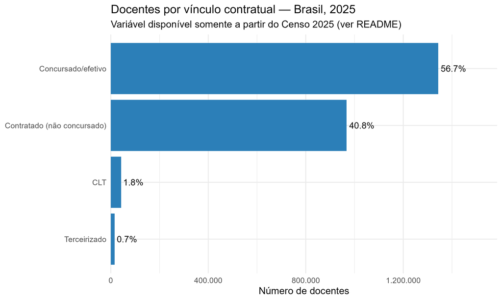

Docentes por vínculo contratual, Brasil, 2025. Fonte: Censo Escolar da Educação Básica (INEP), 2025.

Entre os docentes da rede pública, quase **2 em cada 5** (**40,8%**) não têm vínculo concursado: trabalham sob contrato temporário. Essa é a leitura central deste indicador. As categorias de CLT (1,8%) e terceirizado (0,7%) são residuais em termos nacionais, mas, como se verá na próxima seção, ganham peso em redes específicas. O grupo dos contratados temporários é, disparadamente, o mais exposto a rotatividade, descontinuidade pedagógica e insegurança no emprego, sendo o foco do restante deste relatório.

# 4 Vínculo por rede de ensino

A proporção de docentes contratados varia de forma muito acentuada entre as quatro redes de ensino. Os percentuais desta seção são calculados sobre os docentes com vínculo informado dentro de cada rede (ver seção “Duas formas de calcular os percentuais de vínculo”).

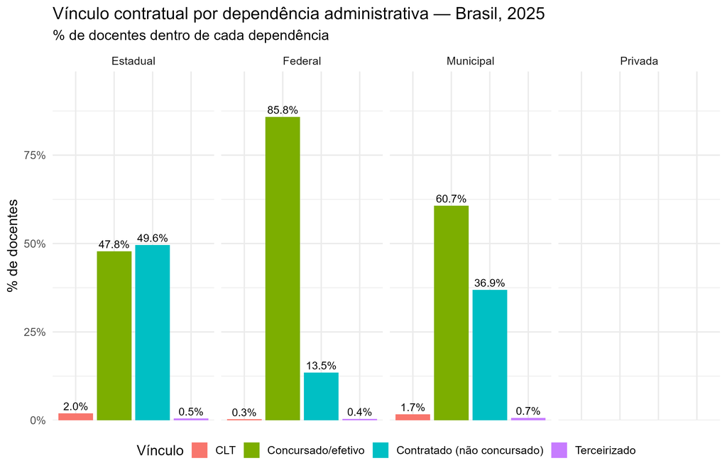

Vínculo contratual por rede de ensino, Brasil, 2025. Fonte: Censo Escolar da Educação Básica (INEP), 2025.

A rede **federal** (40.052 docentes) é a mais estável, com apenas 13,5% de seus docentes contratados e 85,8% concursados/efetivos, refletindo o peso dos institutos federais e universidades federais, historicamente mais estruturados em torno de carreiras concursadas. A rede **estadual** (805.009 docentes) é a mais dividida, com 47,8% concursados contra 49,6% contratados, o que a torna a rede pública com a maior dependência proporcional de contratação temporária e também a que apresenta a maior fração de CLT (2,0%). A rede **municipal** (1.495.329 docentes), embora tenha maioria concursada (60,7%), ainda apresenta uma parcela relevante de contratados (36,9%), sobre a maior base absoluta de docentes do país. Em número de pessoas, isso faz da rede municipal a que concentra o maior contingente absoluto de docentes contratados do país, mesmo não sendo a rede com a maior proporção. A rede **privada** não informa essa variável ao Censo.

# 5 Vínculo por localização

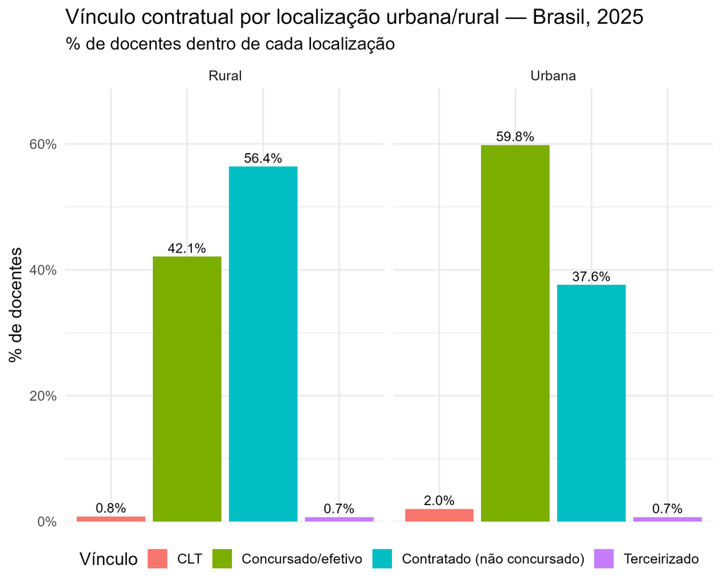

Vínculo contratual por localização urbana e rural, Brasil, 2025. Fonte: Censo Escolar da Educação Básica (INEP), 2025.

A diferença é grande e vai no sentido esperado. Nas escolas rurais (413.464 docentes), a maioria dos docentes (56,4%) é contratada, contra 37,6% nas escolas urbanas (2.578.581 docentes, com 59,8% de concursados). Isso sugere que a fragilidade do vínculo contratual não está distribuída de forma uniforme pelo território, já que escolas rurais, tipicamente mais distantes e com menor atratividade para concursos e fixação de efetivos, dependem proporcionalmente mais de contratação temporária para preencher vagas docentes. Vale notar que a zona rural concentra uma fração pequena do total de docentes (13,8% do total nacional); em termos absolutos, o número de docentes contratados ainda é maior na zona urbana, mas proporcionalmente é na zona rural que o vínculo precário é a norma, não a exceção.

# 6 Vínculo por região e Unidade da Federação

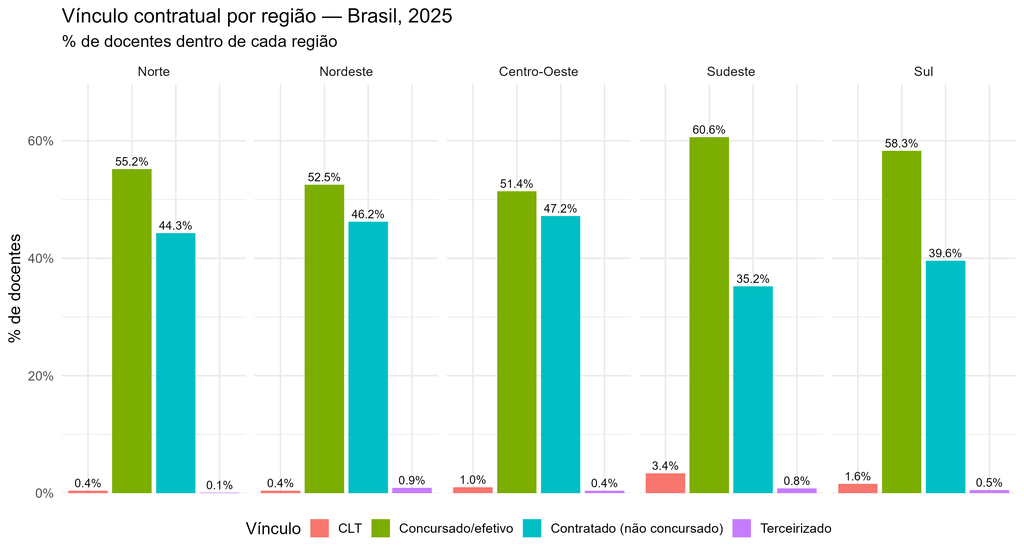

Vínculo contratual por região, Brasil, 2025. Fonte: Censo Escolar da Educação Básica (INEP), 2025.

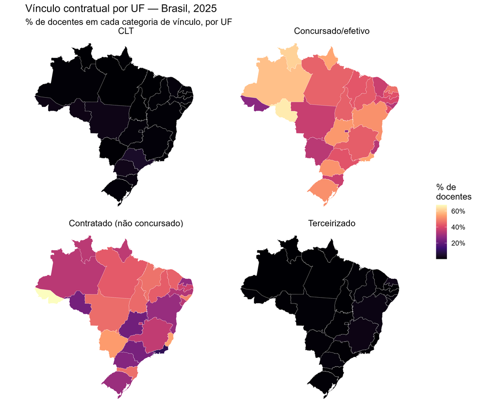

Vínculo contratual por UF e categoria, Brasil, 2025. Fonte: Censo Escolar da Educação Básica (INEP), 2025.

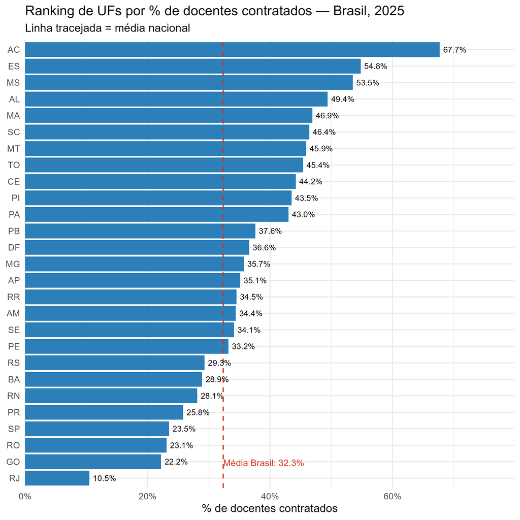

Ranking de UFs por percentual de docentes contratados, Brasil, 2025. Fonte: Censo Escolar da Educação Básica (INEP), 2025.

**Percentual alto não é o mesmo que número alto de pessoas.** O mapa abaixo mostra o total absoluto de docentes por UF. São Paulo concentra, isoladamente, o maior contingente docente do país (601.999 docentes), o que ajuda a interpretar o ranking anterior. Embora o percentual de contratados em São Paulo seja relativamente baixo (23,5%), por ser um estado enorme esse percentual já representa 141.239 docentes contratados em números absolutos, o maior contingente absoluto do país, maior até que o de Minas Gerais (108.341) e muito maior que o do Acre (8.726 docentes contratados, apesar de ter o maior percentual). Ambas as leituras são válidas, mas respondem perguntas diferentes: se a preocupação de política pública for onde estão as maiores taxas de precarização, o Acre lidera; se for onde estão as maiores populações afetadas em números absolutos, São Paulo e Minas Gerais lideram.

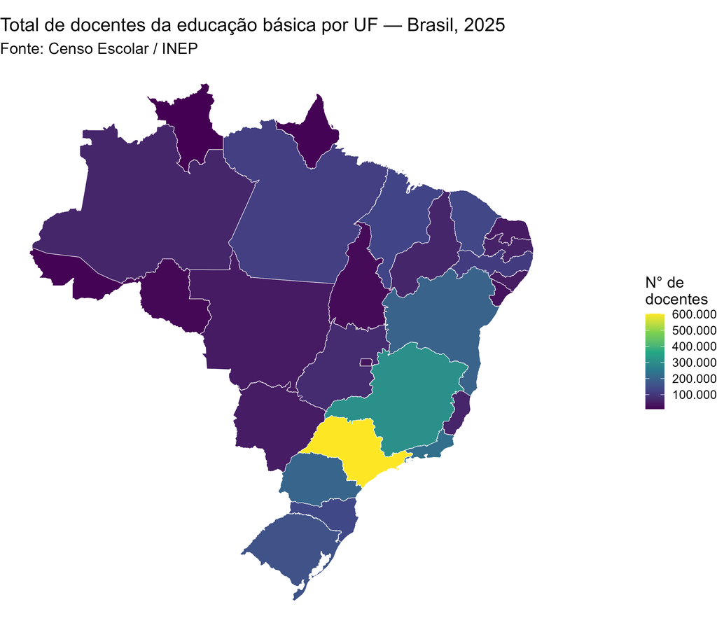

Total de docentes por UF, Brasil, 2025. Fonte: Censo Escolar da Educação Básica (INEP), 2025.

# 7 Heterogeneidade municipal do vínculo contratual

A média de uma UF esconde uma variação interna muito maior entre seus municípios. Para captar essa dimensão, restringimos a análise a municípios com pelo menos 30 docentes, o que evita que municípios muito pequenos, onde um ou dois docentes já mudam o percentual drasticamente, distorçam o retrato.

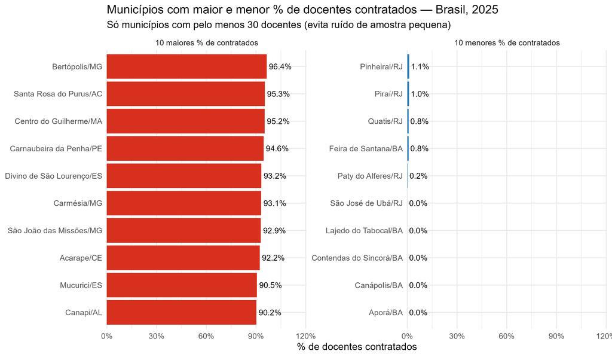

Municípios com maior e menor percentual de docentes contratados, Brasil, 2025. Fonte: Censo Escolar da Educação Básica (INEP), 2025.

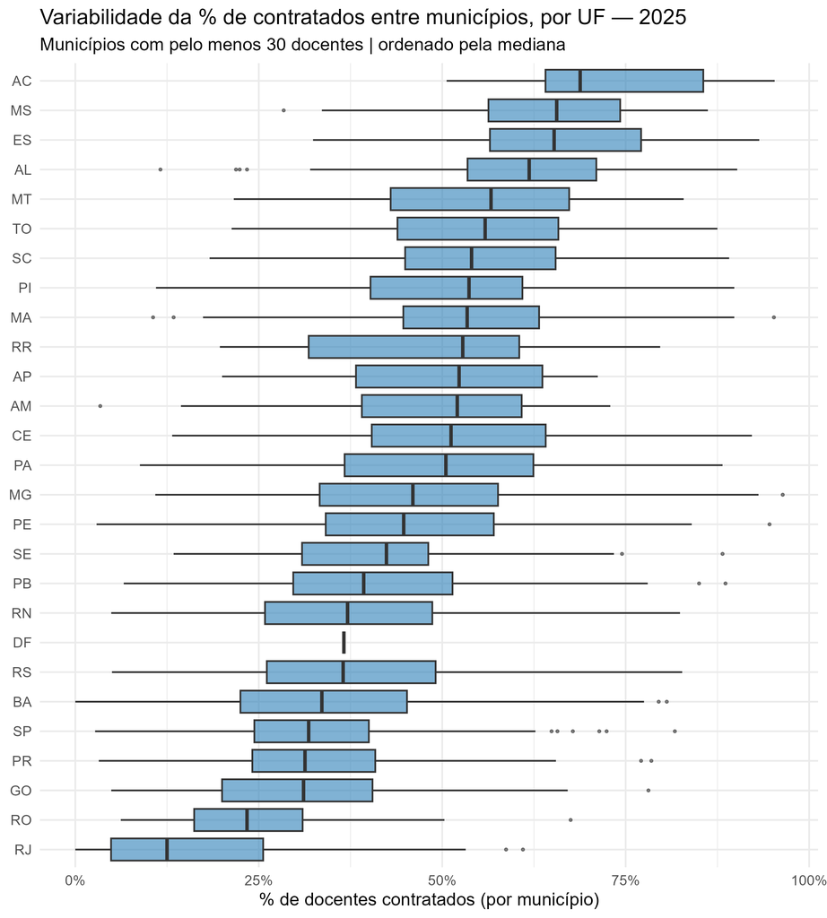

Variabilidade do percentual de docentes contratados entre municípios, por UF, Brasil, 2025. Fonte: Censo Escolar da Educação Básica (INEP), 2025.

A conclusão prática desta seção é que políticas ou diagnósticos formulados apenas no nível de UF podem mascarar realidades municipais muito distintas.

# 8 Evolução do quadro docente por etapa de ensino

Diferente do vínculo contratual, a variável de etapa de ensino existe em toda a série 2015–2025, permitindo observar tendência. Como um mesmo docente pode atuar em mais de uma etapa, as participações a seguir não são mutuamente exclusivas.

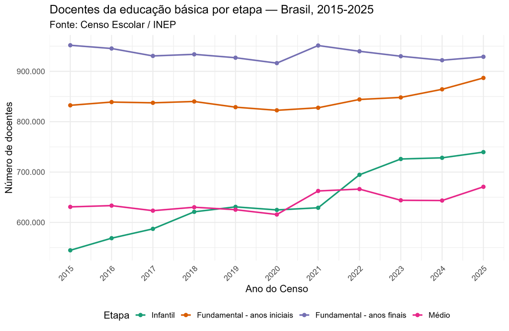

Docentes da educação básica por etapa de ensino, Brasil, 2015-2025. Fonte: Censo Escolar da Educação Básica (INEP), 2015-2025.

O total de docentes da educação básica cresceu 7,4% na década (de 2.784.910 em 2015 para 2.992.045 em 2025), com uma queda temporária entre 2018 e 2020 (provavelmente associada ao início da pandemia de covid-19) seguida de recuperação a partir de 2021. O destaque da década é o crescimento da participação da **educação infantil**, que passou de 19,6% para 24,7% dos docentes, coerente com a expansão de creches e pré-escolas observada no período. Em contrapartida, a participação dos **anos finais do fundamental** recuou de 34,2% para 31,0%. Anos iniciais e ensino médio mantiveram participação relativamente estável.

Olhando a composição por rede (a figura a seguir usa uma escala de eixo Y própria em cada painel, pois as redes têm portes muito diferentes), o padrão de especialização por etapa é nítido:

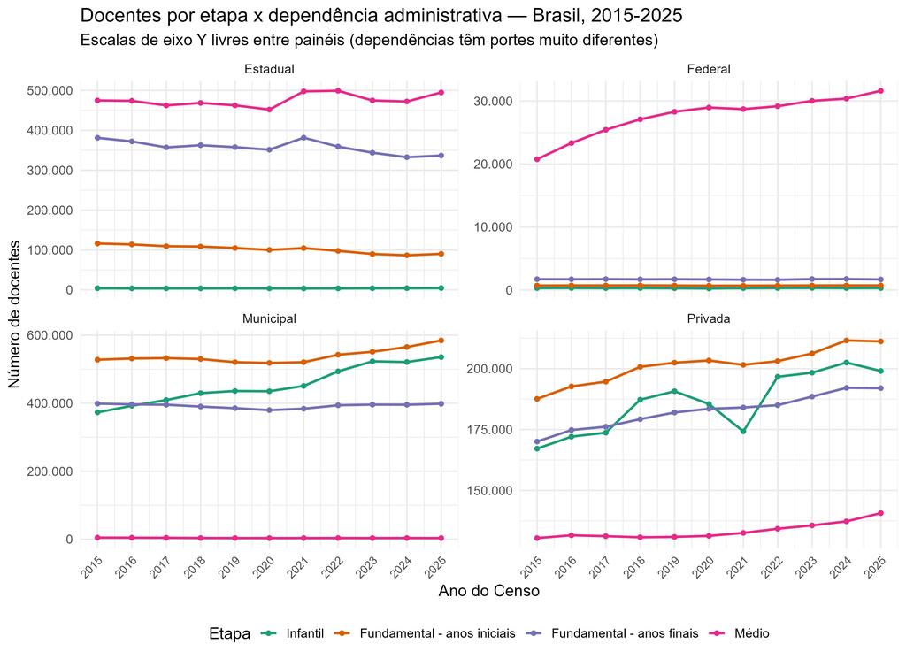

Docentes por etapa de ensino e rede administrativa, Brasil, 2015-2025. Fonte: Censo Escolar da Educação Básica (INEP), 2015-2025.

A rede **federal** é dominada quase inteiramente pelo ensino médio, que cresceu de forma constante ao longo da década (institutos federais); as demais etapas são residuais nessa rede. A rede **estadual** tem o ensino médio como sua maior categoria, seguida pelos anos finais do fundamental; os anos iniciais estaduais estão em queda visível, coerente com o processo histórico de municipalização dessa etapa. A rede **municipal** concentra o maior contingente nos anos iniciais e, com o crescimento mais expressivo da década, na educação infantil; o ensino médio é praticamente inexistente nessa rede. A rede **privada** é a única em que todas as quatro etapas têm presença relevante e crescem ao longo da década.

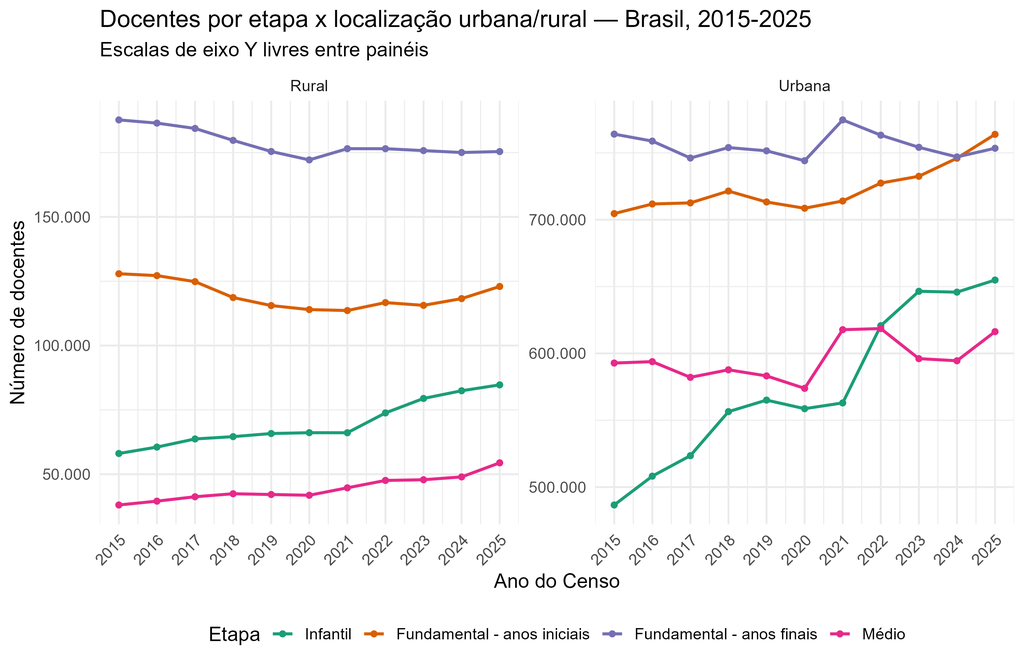

Docentes por etapa de ensino e localização, Brasil, 2015-2025. Fonte: Censo Escolar da Educação Básica (INEP), 2015-2025.

Na zona **rural**, os anos finais do fundamental são a maior categoria ao longo de toda a década, seguidos pelos anos iniciais; a educação infantil e o ensino médio rurais crescem de forma proporcionalmente forte, sinal de uma tentativa de interiorização dessas etapas no campo. Na zona **urbana**, o padrão histórico se inverte ao final da série. Os anos iniciais do fundamental terminam 2025 como a maior categoria, superando os anos finais, e a educação infantil urbana tem o crescimento mais acentuado, com um degrau bem marcado entre 2020 e 2022, coincidindo com o período pós-pandemia.

# 9 Cruzamento entre vínculo contratual e desempenho educacional (IDEB)

Uma pergunta natural, dado o retrato acima, é se a maior dependência de docentes contratados está associada a um IDEB mais baixo. Essa seção testa essa hipótese, restrita à rede pública (federal, estadual e municipal, exceto no ensino médio a nível de UF, onde se usa a rede estadual como proxy, ver seção “Descrição dos dados”), no mesmo ano de referência (2025).

Correlação entre % de docentes contratados e IDEB, por nível e etapa, 2025. Em negrito, as linhas estatisticamente significativas (p < 0,05). Fonte: Censo Escolar da Educação Básica e IDEB (INEP), 2025.

| Nível | Etapa | N | Pearson (r) | Significância (Pearson) | Spearman (rho) | Significância (Spearman) |
| --- | --- | --- | --- | --- | --- | --- |
| **Município** | **Anos Iniciais** | **5.478** | **-0.053** | **p < 0,01** | **-0.094** | **p < 0,01** |
| **Município** | **Anos Finais** | **5.491** | **-0.039** | **p < 0,01** | **-0.088** | **p < 0,01** |
| **Município** | **Ensino Médio** | **5.428** | **-0.110** | **p < 0,01** | **-0.125** | **p < 0,01** |
| UF | Anos Iniciais | 27 | 0.111 | p > 0,05 | 0.121 | p > 0,05 |
| UF | Anos Finais | 27 | 0.056 | p > 0,05 | 0.101 | p > 0,05 |
| UF | Ensino Médio | 27 | 0.077 | p > 0,05 | 0.062 | p > 0,05 |

A leitura correta desses números exige diferenciar dois conceitos que costumam ser confundidos, a **significância estatística** e a **relevância prática**. No nível **município**, com uma amostra grande (entre 5.428 e 5.491 municípios), todas as correlações são estatisticamente significativas a 1%, mas os coeficientes de correlação são muito baixos, o que em termos de magnitude é uma correlação **fraca a desprezível**. Com uma amostra grande, mesmo relações praticamente inexistentes tendem a aparecer como estatisticamente significativas, porque a significância aqui é, em boa parte, um artefato do tamanho da amostra, e não evidência de uma relação forte ou substantiva entre as duas variáveis. No nível **UF**, com apenas 27 observações, nenhuma correlação é estatisticamente significativa, e não há, portanto, evidência estatística de associação alguma.

O sinal da correlação, quando estatisticamente detectável (nível município), é sempre **negativo**, ou seja, mais docentes contratados está associado a um IDEB levemente mais baixo, nunca mais alto. Esse sinal é consistente com a hipótese inicial, mas sua magnitude é pequena demais para sustentar qualquer afirmação de que o tipo de vínculo contratual seja, isoladamente, um fator explicativo relevante das diferenças de IDEB entre municípios.

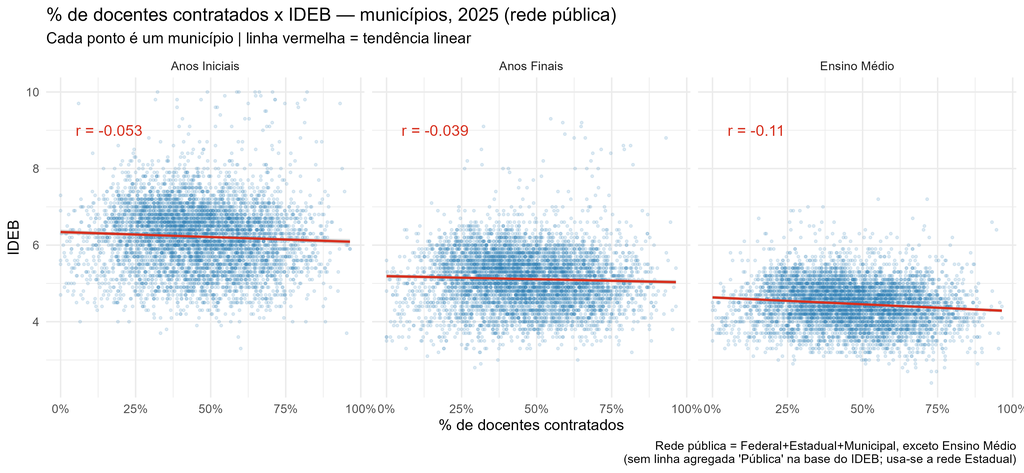

Percentual de docentes contratados e IDEB, por município e etapa, 2025. Fonte: Censo Escolar da Educação Básica e IDEB (INEP), 2025.

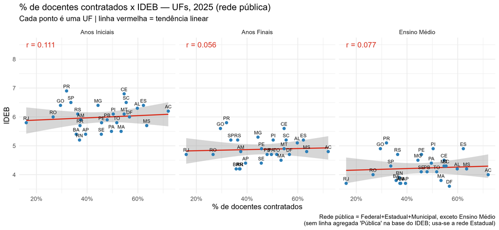

Percentual de docentes contratados e IDEB, por UF e etapa, 2025. Fonte: Censo Escolar da Educação Básica e IDEB (INEP), 2025.

Os gráficos de dispersão (município e UF, um painel por etapa) tornam visível o que os números de correlação já indicam. As nuvens de pontos são dispersas e sem padrão visual claro, com uma linha de tendência praticamente plana, e não há, visualmente, nenhum agrupamento que sugira um efeito de limiar nem uma relação linear forte em nenhuma direção.

# 10 Considerações finais

O corpus de 2.992.045 docentes da educação básica (2025) sustenta as quatro entregas analíticas deste relatório: o panorama do vínculo contratual por rede, localização, região e território, a heterogeneidade municipal, a evolução por etapa de ensino (2015–2025) e o cruzamento com o IDEB 2025.

## 10.1 Principais achados

1. **Quase 2 em cada 5 docentes da rede pública (40,8%) têm vínculo contratado, não concursado.** Entre os docentes com vínculo informado, a maioria ainda é concursada (56,7%), mas a fração de contratados temporários é grande demais para ser tratada como marginal.
2. **A rede privada (21,8% dos docentes) simplesmente não reporta essa informação ao Censo**, o que limita todo o indicador de vínculo à rede pública.
3. **A estabilidade do vínculo varia muito entre as três redes públicas.** A rede federal é a mais estável (13,5% de contratados), a rede estadual é a mais dividida (49,6%), e a rede municipal, apesar de majoritariamente concursada, ainda tem 36,9% de seus docentes sob contrato temporário, sobre a maior base absoluta de docentes do país.
4. **A zona rural depende muito mais de contratação temporária que a zona urbana** (56,4% contra 37,6%), sugerindo que a fragilidade do vínculo contratual está concentrada nas áreas de menor atratividade para fixação de efetivos.
5. **Ao nível de UF, a variação é enorme**, indo de 10,5% no RJ a 67,7% no AC. Percentual alto e número absoluto alto de docentes afetados são leituras diferentes: o AC tem a maior taxa, mas São Paulo e Minas Gerais concentram os maiores contingentes absolutos de contratados do país.
6. **A heterogeneidade municipal é ainda maior que a estadual.** Municípios variam de percentuais próximos de zero a mais de 90% de docentes contratados, muitas vezes dentro da mesma UF, o que indica que diagnósticos formulados apenas no nível estadual podem mascarar realidades municipais completamente distintas.
7. **A educação infantil ganhou peso relativo na década** (19,6% para 24,7% dos docentes), concentrado sobretudo na rede municipal, enquanto os anos finais do fundamental perderam peso (34,2% para 31,0%).
8. **Não há evidência de que o tipo de vínculo contratual, isoladamente, explique diferenças relevantes de desempenho educacional (IDEB).** As correlações são estatisticamente significativas ao nível de município, por conta do tamanho grande da amostra, mas de magnitude muito baixa; ao nível de UF, nenhuma correlação é estatisticamente significativa. O sinal, quando detectável, é sempre negativo, mas pequeno demais para ser tratado como uma explicação central.

## 10.2 Limitações

- O vínculo contratual só está disponível na edição de 2025 do Censo Escolar, sem série histórica, e só é informado pela rede pública, ficando a rede privada fora desse indicador.
- O IDEB não avalia a educação infantil, então o cruzamento cobre apenas anos iniciais, anos finais e ensino médio.
- Na base de UF/região do IDEB, o ensino médio não tem uma linha agregada de rede pública, e a rede estadual foi usada como proxy nesse caso específico.
- As variáveis de etapa de ensino não são mutuamente exclusivas, então participações por etapa podem somar mais de 100% dentro de um grupo.
- A análise é descritiva e correlacional, não causal: a ausência de associação forte com o IDEB não descarta que o vínculo contratual afete a qualidade da educação por vias indiretas, em conjunto com outros fatores não modelados aqui.

# 11 Referências

- INEP. *Censo Escolar da Educação Básica: Microdados*. Disponível em: https://www.gov.br/inep/dados-abertos/microdados/censo-escolar. Acesso em: 23 set. 2026.
- INEP. *IDEB: Resultados e Metas*. Disponível em: https://www.gov.br/inep/pt-br/areas-de-atuacao/pesquisas-estatisticas-e-indicadores/ideb. Acesso em: 23 set. 2026.